```python
import pandas as pd
import numpy as np
import matplotlib.pyplot as plt
import seaborn as sns
import datetime
from sklearn.cluster import KMeans
from sklearn.preprocessing import StandardScaler
import warnings
```

```python
warnings.filterwarnings("ignore")
```

# *Some kinds of segmentation*

*--- Demographic Segmentation*  
*--- Behavioral Segmentation*  
*--- Psychographic Segmentation*  
*--- Lifecycle Segmentation*  
*--- Lifecycle Segmentation*  
*--- Value-Based Segmentation*  
*--- Predictive Segmentation*

# *Explaination of features*

Id: Unique identifier for each individual in the dataset.

Year_Birth: The birth year of the individual.

Education: The highest level of education attained by the individual.

Marital_Status: The marital status of the individual.

Income: The annual income of the individual.

Kidhome: The number of young children in the household.

Teenhome: The number of teenagers in the household.

Dt_Customer: The date when the customer was first enrolled or became a part of the company's database.

Recency: The number of days since the last purchase or interaction.

MntWines: The amount spent on wines.

MntFruits: The amount spent on fruits.

MntMeatProducts: The amount spent on meat products.

MntFishProducts: The amount spent on fish products.

MntSweetProducts: The amount spent on sweet products.

MntGoldProds: The amount spent on gold products.

NumDealsPurchases: The number of purchases made with a discount or as part of a deal.

NumWebPurchases: The number of purchases made through the company's website.

NumCatalogPurchases: The number of purchases made through catalogs.

NumStorePurchases: The number of purchases made in physical stores.

NumWebVisitsMonth: The number of visits to the company's website in a month.

AcceptedCmp3: Binary indicator (1 or 0) whether the individual accepted the third marketing campaign.

AcceptedCmp4: Binary indicator (1 or 0) whether the individual accepted the fourth marketing campaign.

AcceptedCmp5: Binary indicator (1 or 0) whether the individual accepted the fifth marketing campaign.

AcceptedCmp1: Binary indicator (1 or 0) whether the individual accepted the first marketing campaign.

AcceptedCmp2: Binary indicator (1 or 0) whether the individual accepted the second marketing campaign.

Complain: Binary indicator (1 or 0) whether the individual has made a complaint.

Z_CostContact: A constant cost associated with contacting a customer.

Z_Revenue: A constant revenue associated with a successful campaign respon se.

Response: Binary indicator (1 or 0) whether the individual responded to the marketing campaign.

# **Create a dataframe by import CSV file**

```python
df = pd.read_csv(r"C:\Users\Tuan\Desktop\My documents\customer_segmentation.csv")
df.head()
```

|  | ID | Year_Birth | Education | Marital_Status | Income | Kidhome | Teenhome | Dt_Customer | Recency | MntWines | ... | NumWebVisitsMonth | AcceptedCmp3 | AcceptedCmp4 | AcceptedCmp5 | AcceptedCmp1 | AcceptedCmp2 | Complain | Z_CostContact | Z_Revenue | Response |
| --- | --- | --- | --- | --- | --- | --- | --- | --- | --- | --- | --- | --- | --- | --- | --- | --- | --- | --- | --- | --- | --- |
| 0 | 5524 | 1957 | Graduation | Single | 58138.0 | 0 | 0 | 04-09-2012 | 58 | 635 | ... | 7 | 0 | 0 | 0 | 0 | 0 | 0 | 3 | 11 | 1 |
| 1 | 2174 | 1954 | Graduation | Single | 46344.0 | 1 | 1 | 08-03-2014 | 38 | 11 | ... | 5 | 0 | 0 | 0 | 0 | 0 | 0 | 3 | 11 | 0 |
| 2 | 4141 | 1965 | Graduation | Together | 71613.0 | 0 | 0 | 21-08-2013 | 26 | 426 | ... | 4 | 0 | 0 | 0 | 0 | 0 | 0 | 3 | 11 | 0 |
| 3 | 6182 | 1984 | Graduation | Together | 26646.0 | 1 | 0 | 10-02-2014 | 26 | 11 | ... | 6 | 0 | 0 | 0 | 0 | 0 | 0 | 3 | 11 | 0 |
| 4 | 5324 | 1981 | PhD | Married | 58293.0 | 1 | 0 | 19-01-2014 | 94 | 173 | ... | 5 | 0 | 0 | 0 | 0 | 0 | 0 | 3 | 11 | 0 |

5 rows × 29 columns

# **Some infomations about dataset**

*Find missing values*

```python
for col in df.columns:
  if df[col].isnull().sum() > 0:
   print('We have ' + str(round(df[col].isnull().mean() * 100, 2)) + '% missing values in ' + col + ' with ' + str(df[col].isnull().sum()) + ' values' )
```

```
We have 1.07% missing values in Income with 24 values
```

*Fill missing value with median values*

```python
df['Income'] = df['Income'].fillna(df['Income'].median())
```

*Check again if there were any missing values*

```python
for col in df.columns:
  if df[col].isnull().sum() > 0:
   print('We stil have ' + str(round(df[col].isnull().mean() * 100, 2)) + '% missing values in ' + col + ' with ' + str(df[col].isnull().sum()) + ' values' )
  else:
    print('There is no missing values anymore in ' + col)
```

```
There is no missing values anymore in ID
There is no missing values anymore in Year_Birth
There is no missing values anymore in Education
There is no missing values anymore in Marital_Status
There is no missing values anymore in Income
There is no missing values anymore in Kidhome
There is no missing values anymore in Teenhome
There is no missing values anymore in Dt_Customer
There is no missing values anymore in Recency
There is no missing values anymore in MntWines
There is no missing values anymore in MntFruits
There is no missing values anymore in MntMeatProducts
There is no missing values anymore in MntFishProducts
There is no missing values anymore in MntSweetProducts
There is no missing values anymore in MntGoldProds
There is no missing values anymore in NumDealsPurchases
There is no missing values anymore in NumWebPurchases
There is no missing values anymore in NumCatalogPurchases
There is no missing values anymore in NumStorePurchases
There is no missing values anymore in NumWebVisitsMonth
There is no missing values anymore in AcceptedCmp3
There is no missing values anymore in AcceptedCmp4
There is no missing values anymore in AcceptedCmp5
There is no missing values anymore in AcceptedCmp1
There is no missing values anymore in AcceptedCmp2
There is no missing values anymore in Complain
There is no missing values anymore in Z_CostContact
There is no missing values anymore in Z_Revenue
There is no missing values anymore in Response
```

# **I have to draw a histogram in order to show the distribution of Income**

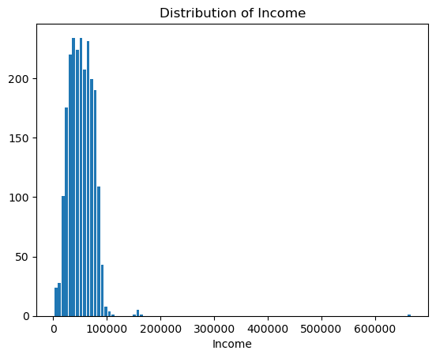

```python
plt.hist(df['Income'], bins = 100, rwidth=0.8)
plt.title('Distribution of Income')
plt.xlabel('Income')
plt.show()
```

**Capacity of Income is around 0 to 100,000, so I will fill all missing values with the median values of the Income columns**

*Find the age of Customers*

```python
df['Age'] = pd.to_datetime('01-07-2014', dayfirst=True).year - df['Year_Birth']
df['Age'].max()
```

```
121
```

# **Show correlation of all the features**

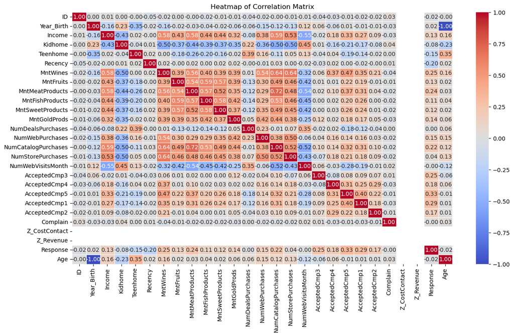

```python
correlation_matrix = df.corr()
plt.figure(figsize=(15, 8))
sns.heatmap(correlation_matrix, annot=True, cmap='coolwarm', fmt=".2f", linewidths=.5)
plt.title('Heatmap of Correlation Matrix')
plt.show()
```

*Create a function to draw a bar chart*

```python
def bar_chart(dataframe, x, y):
  bar_charts = sns.barplot(data=dataframe,x= x,y=y, color='#76a6c0')
  return bar_charts
```

# *Find frequency and monetary value*

*Frequency*

```python
df['Frequency'] = df['NumCatalogPurchases'] + df['NumStorePurchases'] + df['NumWebPurchases']
df['Frequency'].head(10)
```

```
0    22
1     4
2    20
3     6
4    14
5    20
6    17
7     8
8     5
9     1
Name: Frequency, dtype: int64
```

*Monetary value*

```python
df['Monetary'] = df['MntFishProducts'] + df['MntFruits'] + df['MntGoldProds'] + df['MntMeatProducts'] + df['MntSweetProducts'] + df['MntWines']
df['Monetary'].head(10)
```

```
0    1617
1      27
2     776
3      53
4     422
5     716
6     590
7     169
8      46
9      49
Name: Monetary, dtype: int64
```

```python
_df = df[['ID','Recency', 'Frequency', 'Monetary']]
_df.head(10)
```

|  | ID | Recency | Frequency | Monetary |
| --- | --- | --- | --- | --- |
| 0 | 5524 | 58 | 22 | 1617 |
| 1 | 2174 | 38 | 4 | 27 |
| 2 | 4141 | 26 | 20 | 776 |
| 3 | 6182 | 26 | 6 | 53 |
| 4 | 5324 | 94 | 14 | 422 |
| 5 | 7446 | 16 | 20 | 716 |
| 6 | 965 | 34 | 17 | 590 |
| 7 | 6177 | 32 | 8 | 169 |
| 8 | 4855 | 19 | 5 | 46 |
| 9 | 5899 | 68 | 1 | 49 |

# *Using K-Mean to find k parameter*

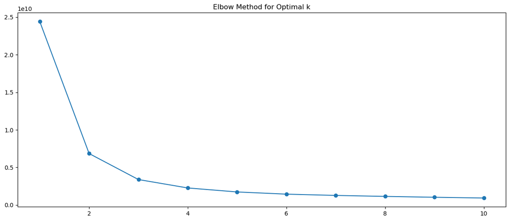

```python
inertia_value = []
for k in range(1,11):
    kmeans = KMeans(n_clusters=k, random_state=42)
    kmeans.fit(_df)
    inertia_value.append(kmeans.inertia_)
plt.figure(figsize=(15,6))
plt.plot(range(1,11), inertia_value, marker='o')
plt.title('Elbow Method for Optimal k')
```

*K value is 4*

# *Fit to model and find clusters*

```python
model = KMeans(n_clusters=4, random_state=42)
model.fit(_df)
_df['Cluster'] = model.labels_
_df.head(10)
```

|  | ID | Recency | Frequency | Monetary | Cluster |
| --- | --- | --- | --- | --- | --- |
| 0 | 5524 | 58 | 22 | 1617 | 2 |
| 1 | 2174 | 38 | 4 | 27 | 1 |
| 2 | 4141 | 26 | 20 | 776 | 2 |
| 3 | 6182 | 26 | 6 | 53 | 3 |
| 4 | 5324 | 94 | 14 | 422 | 2 |
| 5 | 7446 | 16 | 20 | 716 | 3 |
| 6 | 965 | 34 | 17 | 590 | 1 |
| 7 | 6177 | 32 | 8 | 169 | 3 |
| 8 | 4855 | 19 | 5 | 46 | 2 |
| 9 | 5899 | 68 | 1 | 49 | 3 |

```python
ndf = _df.groupby(['Cluster']).agg({
    'Recency': 'mean',
    'Frequency': 'mean',
    'Monetary': 'mean',
}).round(2).reset_index()
ndf
```

|  | Cluster | Recency | Frequency | Monetary |
| --- | --- | --- | --- | --- |
| 0 | 0 | 46.12 | 12.47 | 598.51 |
| 1 | 1 | 49.15 | 12.27 | 595.63 |
| 2 | 2 | 50.82 | 13.05 | 641.36 |
| 3 | 3 | 50.28 | 12.32 | 584.72 |

*---> It does not seem enough to segment customers base on this cluster. Because there is almost no difference in four cluster even when I tried in three cluster. So I have to find another methods for customer segmentation*

# *Demographic analysis*

```python
df.head(10)
```

|  | ID | Year_Birth | Education | Marital_Status | Income | Kidhome | Teenhome | Dt_Customer | Recency | MntWines | ... | AcceptedCmp5 | AcceptedCmp1 | AcceptedCmp2 | Complain | Z_CostContact | Z_Revenue | Response | Age | Frequency | Monetary |
| --- | --- | --- | --- | --- | --- | --- | --- | --- | --- | --- | --- | --- | --- | --- | --- | --- | --- | --- | --- | --- | --- |
| 0 | 5524 | 1957 | Graduation | Single | 58138.0 | 0 | 0 | 04-09-2012 | 58 | 635 | ... | 0 | 0 | 0 | 0 | 3 | 11 | 1 | 57 | 22 | 1617 |
| 1 | 2174 | 1954 | Graduation | Single | 46344.0 | 1 | 1 | 08-03-2014 | 38 | 11 | ... | 0 | 0 | 0 | 0 | 3 | 11 | 0 | 60 | 4 | 27 |
| 2 | 4141 | 1965 | Graduation | Together | 71613.0 | 0 | 0 | 21-08-2013 | 26 | 426 | ... | 0 | 0 | 0 | 0 | 3 | 11 | 0 | 49 | 20 | 776 |
| 3 | 6182 | 1984 | Graduation | Together | 26646.0 | 1 | 0 | 10-02-2014 | 26 | 11 | ... | 0 | 0 | 0 | 0 | 3 | 11 | 0 | 30 | 6 | 53 |
| 4 | 5324 | 1981 | PhD | Married | 58293.0 | 1 | 0 | 19-01-2014 | 94 | 173 | ... | 0 | 0 | 0 | 0 | 3 | 11 | 0 | 33 | 14 | 422 |
| 5 | 7446 | 1967 | Master | Together | 62513.0 | 0 | 1 | 09-09-2013 | 16 | 520 | ... | 0 | 0 | 0 | 0 | 3 | 11 | 0 | 47 | 20 | 716 |
| 6 | 965 | 1971 | Graduation | Divorced | 55635.0 | 0 | 1 | 13-11-2012 | 34 | 235 | ... | 0 | 0 | 0 | 0 | 3 | 11 | 0 | 43 | 17 | 590 |
| 7 | 6177 | 1985 | PhD | Married | 33454.0 | 1 | 0 | 08-05-2013 | 32 | 76 | ... | 0 | 0 | 0 | 0 | 3 | 11 | 0 | 29 | 8 | 169 |
| 8 | 4855 | 1974 | PhD | Together | 30351.0 | 1 | 0 | 06-06-2013 | 19 | 14 | ... | 0 | 0 | 0 | 0 | 3 | 11 | 1 | 40 | 5 | 46 |
| 9 | 5899 | 1950 | PhD | Together | 5648.0 | 1 | 1 | 13-03-2014 | 68 | 28 | ... | 0 | 0 | 0 | 0 | 3 | 11 | 0 | 64 | 1 | 49 |

10 rows × 32 columns

*Create a dataframe of demographic*

```python
gdf = df[['ID','Income', 'Kidhome', 'Teenhome','Recency', 'Age']]
```

```python
gdf = gdf[(gdf['Income'] < 600000) & (gdf['Age'] < 100)]
gdf.head(10)
```

|  | ID | Income | Kidhome | Teenhome | Recency | Age |
| --- | --- | --- | --- | --- | --- | --- |
| 0 | 5524 | 58138.0 | 0 | 0 | 58 | 57 |
| 1 | 2174 | 46344.0 | 1 | 1 | 38 | 60 |
| 2 | 4141 | 71613.0 | 0 | 0 | 26 | 49 |
| 3 | 6182 | 26646.0 | 1 | 0 | 26 | 30 |
| 4 | 5324 | 58293.0 | 1 | 0 | 94 | 33 |
| 5 | 7446 | 62513.0 | 0 | 1 | 16 | 47 |
| 6 | 965 | 55635.0 | 0 | 1 | 34 | 43 |
| 7 | 6177 | 33454.0 | 1 | 0 | 32 | 29 |
| 8 | 4855 | 30351.0 | 1 | 0 | 19 | 40 |
| 9 | 5899 | 5648.0 | 1 | 1 | 68 | 64 |

*Find k parameter*

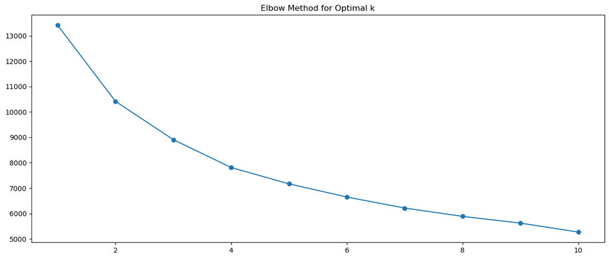

```python
scaler = StandardScaler()
features = scaler.fit_transform(gdf)
inertia_value = []
for k in range(1,11):
    kmeans = KMeans(n_clusters=k, random_state=42)
    kmeans.fit(features)
    inertia_value.append(kmeans.inertia_)
plt.figure(figsize=(15,6))
plt.plot(range(1,11), inertia_value, marker='o')
plt.title('Elbow Method for Optimal k')
```

*K-mean model when k = 4*

```python
model = KMeans(n_clusters=4, random_state=42)
model.fit(features)
gdf['Cluster'] = model.labels_
gdf.head(10)
```

|  | ID | Income | Kidhome | Teenhome | Recency | Age | Cluster |
| --- | --- | --- | --- | --- | --- | --- | --- |
| 0 | 5524 | 58138.0 | 0 | 0 | 58 | 57 | 3 |
| 1 | 2174 | 46344.0 | 1 | 1 | 38 | 60 | 0 |
| 2 | 4141 | 71613.0 | 0 | 0 | 26 | 49 | 3 |
| 3 | 6182 | 26646.0 | 1 | 0 | 26 | 30 | 1 |
| 4 | 5324 | 58293.0 | 1 | 0 | 94 | 33 | 1 |
| 5 | 7446 | 62513.0 | 0 | 1 | 16 | 47 | 2 |
| 6 | 965 | 55635.0 | 0 | 1 | 34 | 43 | 2 |
| 7 | 6177 | 33454.0 | 1 | 0 | 32 | 29 | 1 |
| 8 | 4855 | 30351.0 | 1 | 0 | 19 | 40 | 1 |
| 9 | 5899 | 5648.0 | 1 | 1 | 68 | 64 | 0 |

*Merge two dataframe ti a new dataframe*

```python
new = pd.merge(gdf, df, on='ID', how='inner')
new.head(10)
```

|  | ID | Income_x | Kidhome_x | Teenhome_x | Recency_x | Age_x | Cluster | Year_Birth | Education | Marital_Status | ... | AcceptedCmp5 | AcceptedCmp1 | AcceptedCmp2 | Complain | Z_CostContact | Z_Revenue | Response | Age_y | Frequency | Monetary |
| --- | --- | --- | --- | --- | --- | --- | --- | --- | --- | --- | --- | --- | --- | --- | --- | --- | --- | --- | --- | --- | --- |
| 0 | 5524 | 58138.0 | 0 | 0 | 58 | 57 | 3 | 1957 | Graduation | Single | ... | 0 | 0 | 0 | 0 | 3 | 11 | 1 | 57 | 22 | 1617 |
| 1 | 2174 | 46344.0 | 1 | 1 | 38 | 60 | 0 | 1954 | Graduation | Single | ... | 0 | 0 | 0 | 0 | 3 | 11 | 0 | 60 | 4 | 27 |
| 2 | 4141 | 71613.0 | 0 | 0 | 26 | 49 | 3 | 1965 | Graduation | Together | ... | 0 | 0 | 0 | 0 | 3 | 11 | 0 | 49 | 20 | 776 |
| 3 | 6182 | 26646.0 | 1 | 0 | 26 | 30 | 1 | 1984 | Graduation | Together | ... | 0 | 0 | 0 | 0 | 3 | 11 | 0 | 30 | 6 | 53 |
| 4 | 5324 | 58293.0 | 1 | 0 | 94 | 33 | 1 | 1981 | PhD | Married | ... | 0 | 0 | 0 | 0 | 3 | 11 | 0 | 33 | 14 | 422 |
| 5 | 7446 | 62513.0 | 0 | 1 | 16 | 47 | 2 | 1967 | Master | Together | ... | 0 | 0 | 0 | 0 | 3 | 11 | 0 | 47 | 20 | 716 |
| 6 | 965 | 55635.0 | 0 | 1 | 34 | 43 | 2 | 1971 | Graduation | Divorced | ... | 0 | 0 | 0 | 0 | 3 | 11 | 0 | 43 | 17 | 590 |
| 7 | 6177 | 33454.0 | 1 | 0 | 32 | 29 | 1 | 1985 | PhD | Married | ... | 0 | 0 | 0 | 0 | 3 | 11 | 0 | 29 | 8 | 169 |
| 8 | 4855 | 30351.0 | 1 | 0 | 19 | 40 | 1 | 1974 | PhD | Together | ... | 0 | 0 | 0 | 0 | 3 | 11 | 1 | 40 | 5 | 46 |
| 9 | 5899 | 5648.0 | 1 | 1 | 68 | 64 | 0 | 1950 | PhD | Together | ... | 0 | 0 | 0 | 0 | 3 | 11 | 0 | 64 | 1 | 49 |

10 rows × 38 columns

*Using RFM method for customer segmentation*

```python
clusters = new.groupby('Cluster').agg({
    'Recency_y': 'mean',
    'Frequency': 'mean',
    'Monetary': 'mean',
}).round(2).reset_index()
clusters
```

|  | Cluster | Recency_y | Frequency | Monetary |
| --- | --- | --- | --- | --- |
| 0 | 0 | 49.67 | 8.08 | 222.86 |
| 1 | 1 | 48.71 | 6.93 | 157.47 |
| 2 | 2 | 48.74 | 15.79 | 695.15 |
| 3 | 3 | 49.59 | 18.26 | 1287.09 |

*---> I found that we can segment our customer to four different group:*  
*1. I will call those whose frequency and monetary have the lowest value is Silver Type*  
*2. The higher frequencies and monetaries I will call Gold Type*  
*3. The second place of the height of frequencies and monetaries I will call Platinum Type*  
*4. And the last type of customers who have the highest frequencies and monetaries I will cal Diamond type*

```python
new['Cluster'] = new['Cluster'].map({
    1: 'Silver',
    0: 'Gold',
    2: 'Platinum',
    3: 'Diamond',
})
new.head(5)
```

|  | ID | Income_x | Kidhome_x | Teenhome_x | Recency_x | Age_x | Cluster | Year_Birth | Education | Marital_Status | ... | AcceptedCmp5 | AcceptedCmp1 | AcceptedCmp2 | Complain | Z_CostContact | Z_Revenue | Response | Age_y | Frequency | Monetary |
| --- | --- | --- | --- | --- | --- | --- | --- | --- | --- | --- | --- | --- | --- | --- | --- | --- | --- | --- | --- | --- | --- |
| 0 | 5524 | 58138.0 | 0 | 0 | 58 | 57 | Diamond | 1957 | Graduation | Single | ... | 0 | 0 | 0 | 0 | 3 | 11 | 1 | 57 | 22 | 1617 |
| 1 | 2174 | 46344.0 | 1 | 1 | 38 | 60 | Gold | 1954 | Graduation | Single | ... | 0 | 0 | 0 | 0 | 3 | 11 | 0 | 60 | 4 | 27 |
| 2 | 4141 | 71613.0 | 0 | 0 | 26 | 49 | Diamond | 1965 | Graduation | Together | ... | 0 | 0 | 0 | 0 | 3 | 11 | 0 | 49 | 20 | 776 |
| 3 | 6182 | 26646.0 | 1 | 0 | 26 | 30 | Silver | 1984 | Graduation | Together | ... | 0 | 0 | 0 | 0 | 3 | 11 | 0 | 30 | 6 | 53 |
| 4 | 5324 | 58293.0 | 1 | 0 | 94 | 33 | Silver | 1981 | PhD | Married | ... | 0 | 0 | 0 | 0 | 3 | 11 | 0 | 33 | 14 | 422 |

5 rows × 38 columns

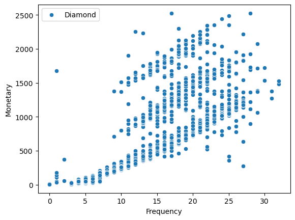

```python
sns.scatterplot(data = new,x='Frequency', y='Monetary')
plt.legend(new['Cluster'])
```

```python
new.rename({
    'Income_x': 'Income',
    'Kidhome_x': 'Kidhome',
    'Teenhome_x': 'Teenhome',
    'Recency_x': 'Recency',
    'Age_x': 'Age',
}, axis=1, inplace=True)
new.head(10)
```

|  | ID | Income | Kidhome | Teenhome | Recency | Age | Cluster | Year_Birth | Education | Marital_Status | ... | AcceptedCmp5 | AcceptedCmp1 | AcceptedCmp2 | Complain | Z_CostContact | Z_Revenue | Response | Age_y | Frequency | Monetary |
| --- | --- | --- | --- | --- | --- | --- | --- | --- | --- | --- | --- | --- | --- | --- | --- | --- | --- | --- | --- | --- | --- |
| 0 | 5524 | 58138.0 | 0 | 0 | 58 | 57 | Diamond | 1957 | Graduation | Single | ... | 0 | 0 | 0 | 0 | 3 | 11 | 1 | 57 | 22 | 1617 |
| 1 | 2174 | 46344.0 | 1 | 1 | 38 | 60 | Gold | 1954 | Graduation | Single | ... | 0 | 0 | 0 | 0 | 3 | 11 | 0 | 60 | 4 | 27 |
| 2 | 4141 | 71613.0 | 0 | 0 | 26 | 49 | Diamond | 1965 | Graduation | Together | ... | 0 | 0 | 0 | 0 | 3 | 11 | 0 | 49 | 20 | 776 |
| 3 | 6182 | 26646.0 | 1 | 0 | 26 | 30 | Silver | 1984 | Graduation | Together | ... | 0 | 0 | 0 | 0 | 3 | 11 | 0 | 30 | 6 | 53 |
| 4 | 5324 | 58293.0 | 1 | 0 | 94 | 33 | Silver | 1981 | PhD | Married | ... | 0 | 0 | 0 | 0 | 3 | 11 | 0 | 33 | 14 | 422 |
| 5 | 7446 | 62513.0 | 0 | 1 | 16 | 47 | Platinum | 1967 | Master | Together | ... | 0 | 0 | 0 | 0 | 3 | 11 | 0 | 47 | 20 | 716 |
| 6 | 965 | 55635.0 | 0 | 1 | 34 | 43 | Platinum | 1971 | Graduation | Divorced | ... | 0 | 0 | 0 | 0 | 3 | 11 | 0 | 43 | 17 | 590 |
| 7 | 6177 | 33454.0 | 1 | 0 | 32 | 29 | Silver | 1985 | PhD | Married | ... | 0 | 0 | 0 | 0 | 3 | 11 | 0 | 29 | 8 | 169 |
| 8 | 4855 | 30351.0 | 1 | 0 | 19 | 40 | Silver | 1974 | PhD | Together | ... | 0 | 0 | 0 | 0 | 3 | 11 | 1 | 40 | 5 | 46 |
| 9 | 5899 | 5648.0 | 1 | 1 | 68 | 64 | Gold | 1950 | PhD | Together | ... | 0 | 0 | 0 | 0 | 3 | 11 | 0 | 64 | 1 | 49 |

10 rows × 38 columns

```python
new.to_csv("C:/Users/Tuan/Desktop/Blog/Porfolio/Customers_segmentation.csv", index=False)
```